# Correct stake and trees coordinates

## Plot

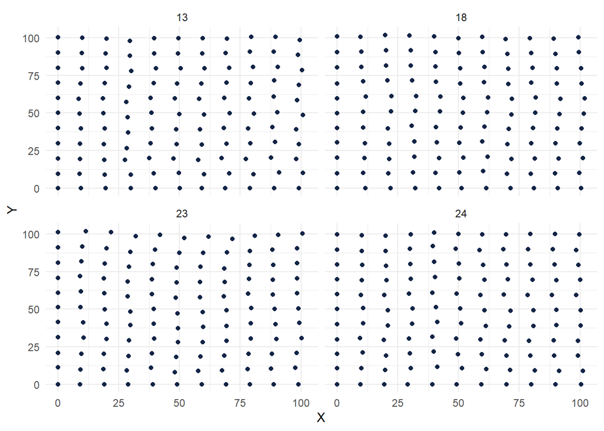

```r
ggplot(Piquets_Paracou) +
  aes(x = X, y = Y) +
  geom_point(shape = "circle", size = 1.5, colour = "#112446") +
  theme_minimal() +
  facet_wrap(vars(plot))
```

# Theoric place

piquets espacés de 10x10  
## Data filling

```r
Piquets_theor <- Piquets_Paracou %>%
  select(plot, quadra.nb.X, quadra.nb.Y) %>%
  mutate(X = NA) %>%
  mutate(Y = NA)

# Remplir Y pour tous les X

for(p in plots){ # for each plot
  for (x in 0:10){ # for each X

    Y <- c(0, rep(NA, 10))

    Y_length <- rep(10, 10)

    for(i in 1:10){ # for each subplot
      Y[i+1] = Y[i] + Y_length[i]
    }

    # Y_length
    # Y

    Piquets_theor[Piquets_theor$plot==p &
                    Piquets_theor$quadra.nb.X == x,]$Y <- Y
  }
}
```

```r
# Remplir X pour tous les Y

for(p in plots){ # for each plot
  for (y in 0:10){ # for each Y
    X <- c(0, rep(NA, 10))

    X_length <- rep(10, 10)

    for(i in 1:10){ # for each subplot
      X[i+1] = X[i] + X_length[i]
    }

    Piquets_theor[Piquets_theor$plot==p &
                    Piquets_theor$quadra.nb.Y == y,]$X <- X
  }
}
```

## Plot

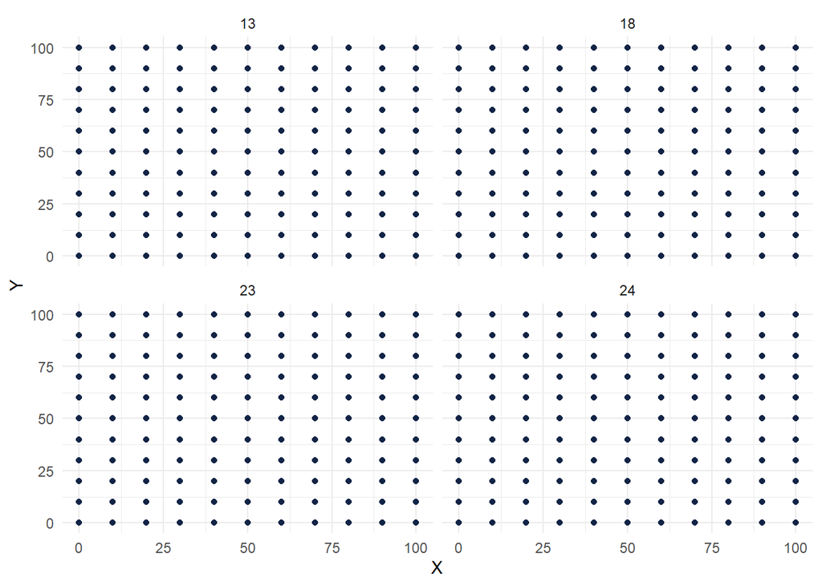

```r
ggplot(Piquets_theor) +
  aes(x = X, y = Y) +
  geom_point(shape = "circle", size = 1.5, colour = "#112446") +
  theme_minimal() +
  facet_wrap(vars(plot))
```

## Plot both

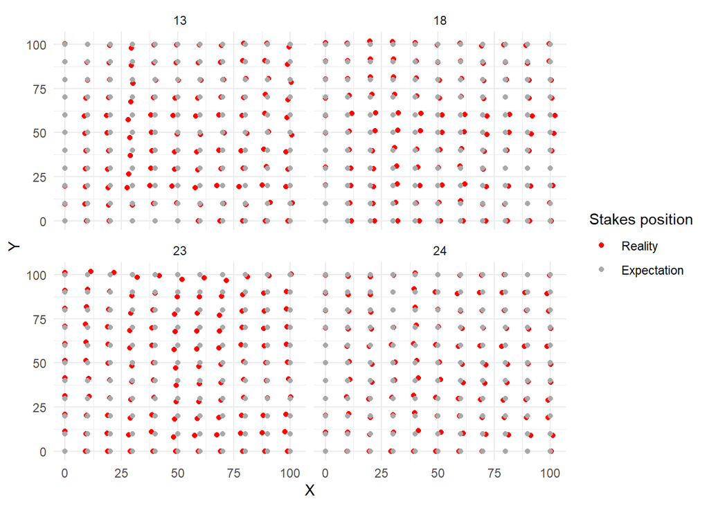

```r
ggplot(Piquets_Paracou) +
  aes(x = X, y = Y, colour = quadra.nb.X) +
  geom_point(shape = "circle", size = 1.5,
             aes(colour = "Reality")) +
  theme_minimal() +
  facet_wrap(vars(plot)) +
  geom_point(data = Piquets_theor, aes(x = X, y = Y, colour = "Expectation"), shape = "circle", size = 1.5) +
  theme_minimal() +
  facet_wrap(vars(plot)) +
  scale_colour_manual(values = c("Reality" = "red",
                                 "Expectation" = "darkgrey"),
                      breaks=c("Reality", "Expectation")) +
  labs(color = "Stakes position")
```

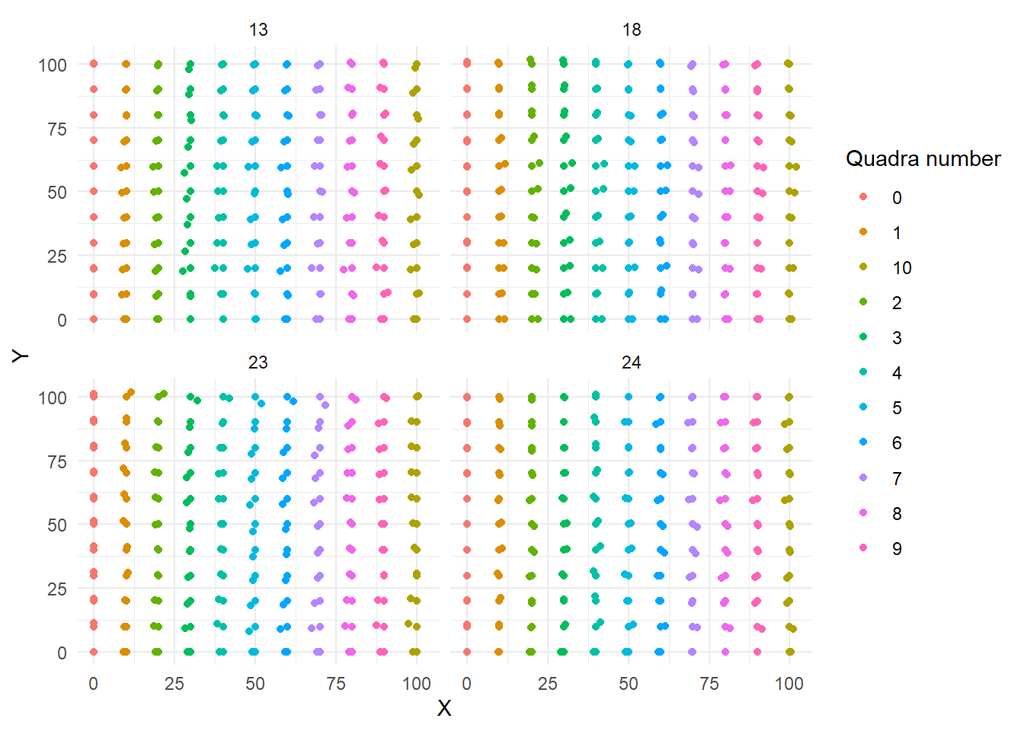

```r
ggplot(Piquets_Paracou) +
  aes(x = X, y = Y, colour = as.character(quadra.nb.X)) +
  geom_point(shape = "circle", size = 1.5) +
  theme_minimal() +
  facet_wrap(vars(plot)) +
  geom_point(data = Piquets_theor, shape = "circle", size = 1.5) +
  theme_minimal() +
  facet_wrap(vars(plot)) +
  scale_fill_brewer(palette = "Blues") +
  # scale_colour_manual(breaks=c(as.character(0:10))) +
  labs(color = "Quadra number")
```

# Correction des coordonnées des arbres (A FAIRE)

1. Les 4 coins du carré de 1 ha sont eux normalement bien positionnés.  
   Nous les prendrons comme référence en projetant les piquets de manière à ce que les 4 coins du carré de 1 ha soient bien représentés (100x100m) (= que le point rouge se superpose au point gris)  
   Méthode à chercher : interpolation polynomiale de degré 2 (voir gdalwarp), sur qgis ou R

Après avoir reprojeté les piquets selon ces bornes, on obtient les coordonnées corrigées de chaque piquet

2. et on recalcule les coordonnées des arbres relatives au coin Sud-Ouest corrigé de chaque quadrat.

Subsistera l’erreur de mesure des distances.

## Reprojection des piquets selon les coins du carré

## Correction des coordonées des arbres selon les piquets S-O corrigés